# Notes P

Pretty Documents: Colors, Themes, and Scales

```r
#LOAD PACKAGES
library(tidyverse)
```

# Themes

If you want to set your ggplot theme globally (for the whole document) you can use this code:

```r
theme_set(theme_minimal())
```

# Colors

## Default Colors

```r
bp <- ggplot(iris, aes(Species, Sepal.Length)) +
  geom_boxplot(aes(fill = Species)) +
  theme_minimal() +
  theme(legend.position = "top")
bp

# Scatter plot
sp <- ggplot(iris, aes(Sepal.Length, Sepal.Width)) +
  geom_point(aes(color = Petal.Length)) +
  theme_minimal()+
  theme(legend.position = "top")
sp
```

[output not shown]

## On a plot

For a plot you can create a custom color palette:

|  | color | fill |
| --- | --- | --- |
|  | This will be applied to points, lines and texts | This will change the fill color of areas, such as in box plot, bar plot, histogram, density plots, etc. |
| discrete | `scale_color_manual` | `scale_fill_manual` |
| continuous | `scale_color_gradient` | `scale_fill_gradient` |
| want continuous from discrete scale | `scale_color_distill` | `scale_fill_distill` |

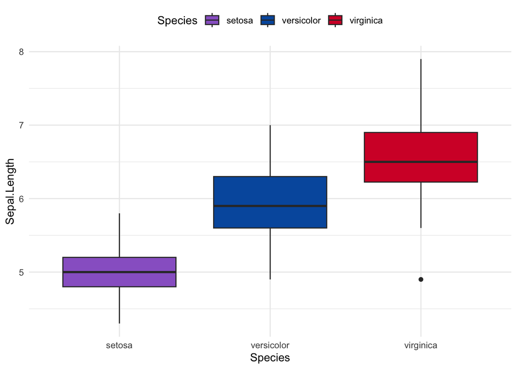

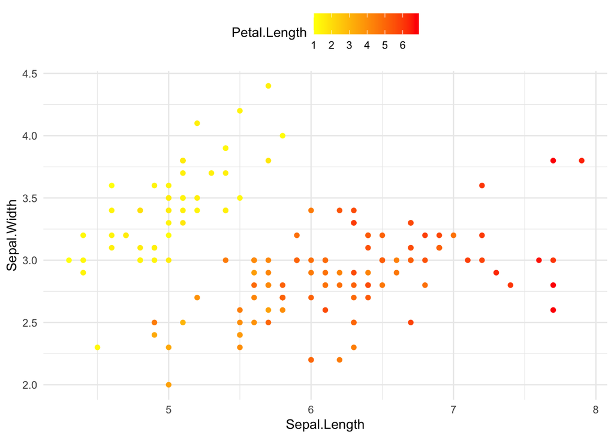

```r
bp
bp +
  scale_fill_manual(values=c("#9966cc", "#005bac", "#d50032"))
sp
sp +
  scale_colour_gradient(low = "yellow", high = "red")
```

## Color Palettes: `colorBrewer`

The RColorBrewer package creates a nice looking color palettes.

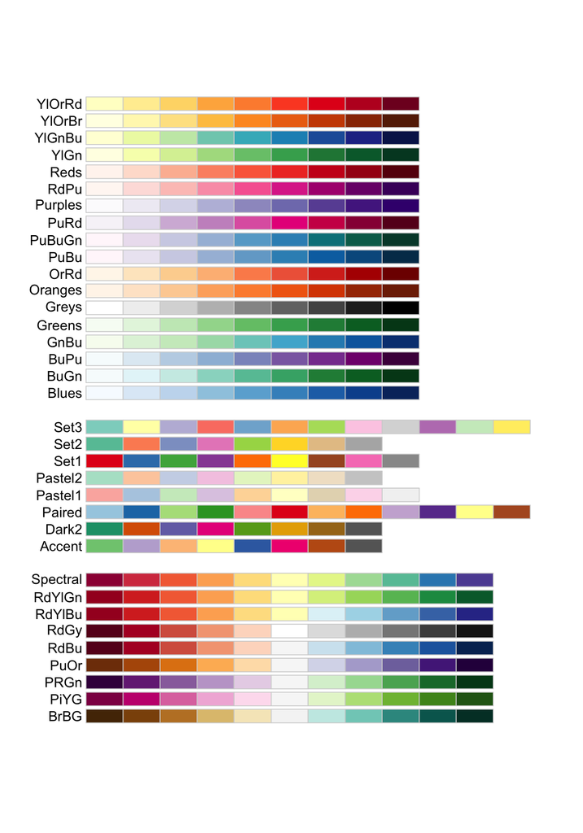

```r
library(RColorBrewer)
display.brewer.all()
```

- **Sequential palettes** (first list of colors), which are suited to ordered data that progress from low to high (gradient). The palettes names are : Blues, BuGn, BuPu, GnBu, Greens, Greys, Oranges, OrRd, PuBu, PuBuGn, PuRd, Purples, RdPu, Reds, YlGn, YlGnBu YlOrBr, YlOrRd.
- **Qualitative palettes** (second list of colors), which are best suited to represent nominal or categorical data. They not imply magnitude differences between groups. The palettes names are : Accent, Dark2, Paired, Pastel1, Pastel2, Set1, Set2, Set3.
- **Diverging palettes** (third list of colors), which put equal emphasis on mid-range critical values and extremes at both ends of the data range. The diverging palettes are : BrBG, PiYG, PRGn, PuOr, RdBu, RdGy, RdYlBu, RdYlGn, Spectral

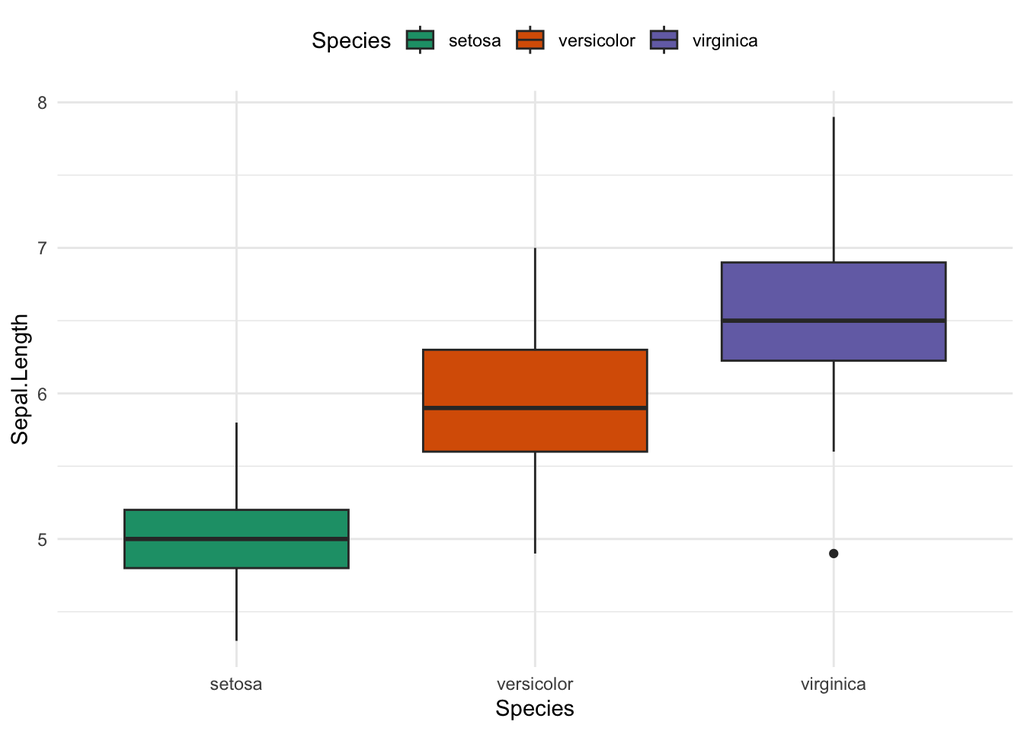

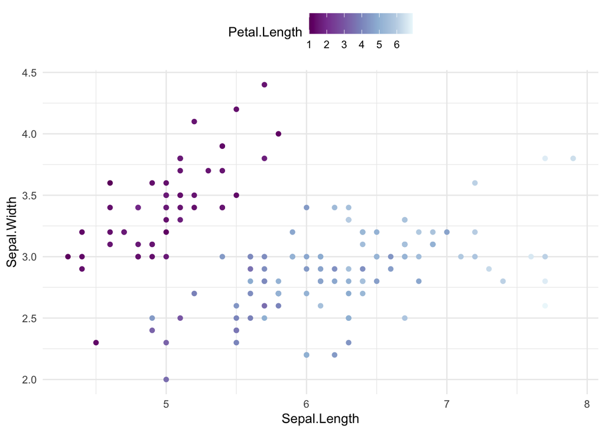

```r
bp
bp +
  scale_fill_brewer(palette = "Dark2")
sp
sp +
  scale_color_distiller(palette = "BuPu")
```

## Other Cool Palettes

- `ggsci`
- `wesanderson`
- `tayloRswift`

# Global Custom Color Palettes

If you want to set your ggplot colors globally (for the whole document) you can use this code:

```r
options(ggplot2.discrete.color= c("#9966cc", "#005bac", "#d50032", "#c9b037", "#3D424D"),
        ggplot2.discrete.fill = c("#9966cc", "#005bac", "#d50032", "#c9b037", "#3D424D"))
```

# Legends

## hide the legend

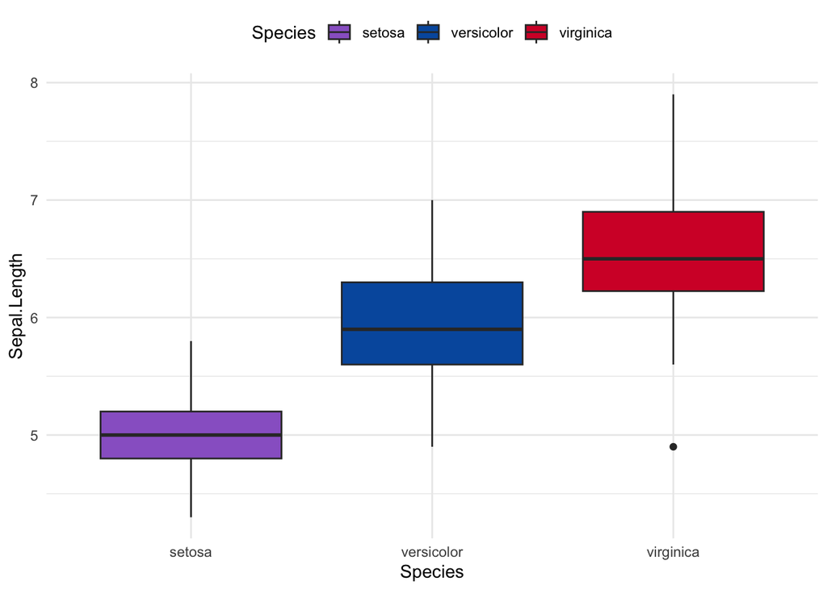

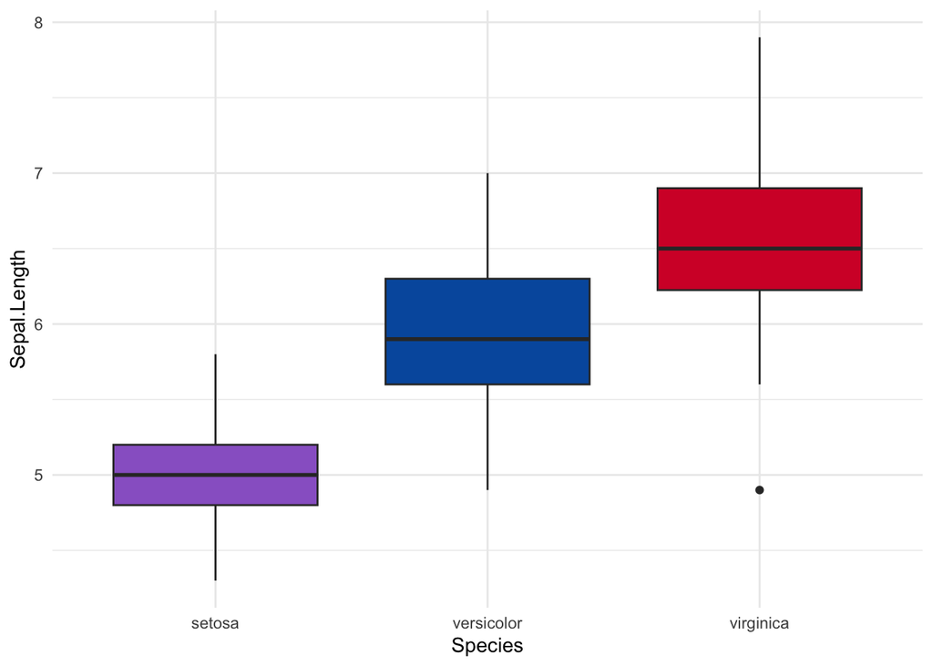

```r
bp
bp +
  guides(fill="none")
```

## customizing title of legend

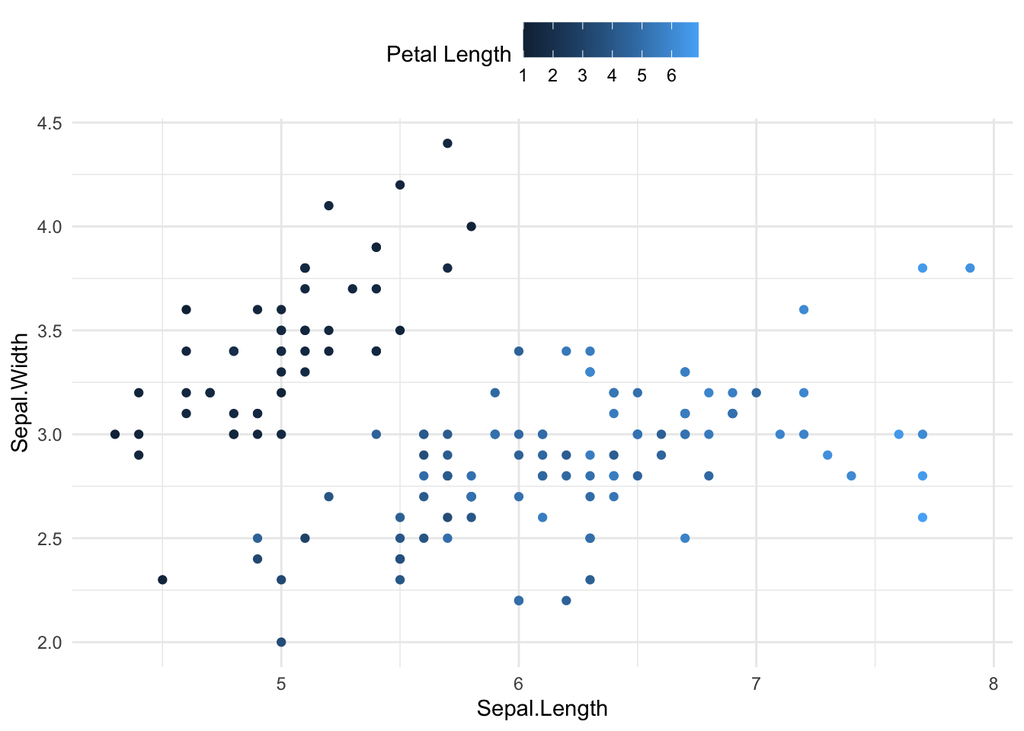

```r
sp
sp +
  scale_color_continuous(name="Petal Length")
```

# Axes and scales

## customizing axes breaks

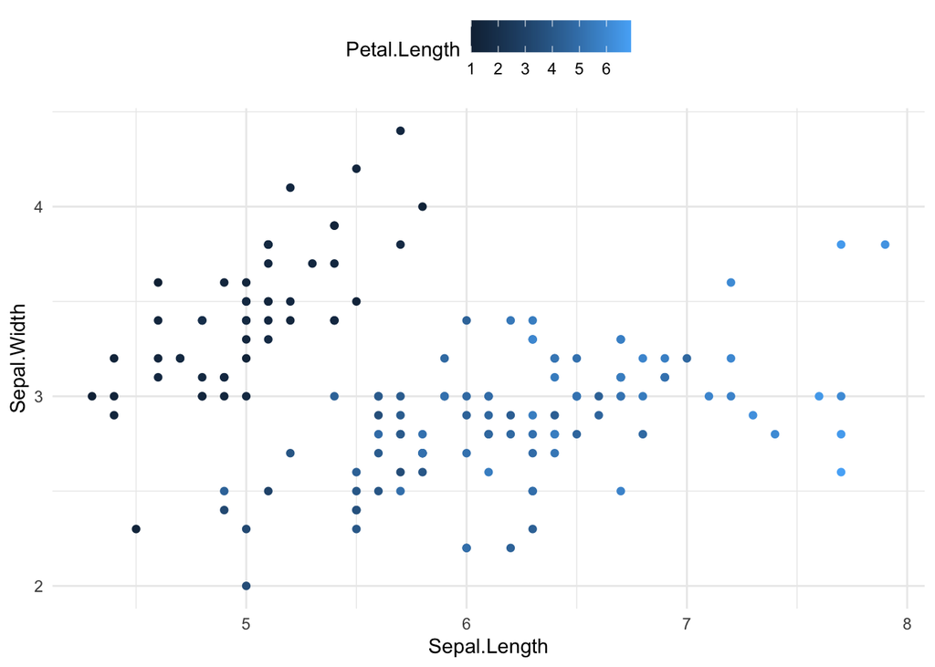

```r
sp
sp +
  scale_y_continuous(breaks=c(2,3,4,5))
```